# DEM 7263 - Clustering of Spatial Data

Corey S. Sparks, Ph.D.

25 October, 2021

```
## To access larger datasets in this package, install the spDataLarge
## package with: `install.packages('spDataLarge',
## repos='https://nowosad.github.io/drat/', type='source')`
```

In this topic, we will discuss **Unsupervised Learning**, or as we talked about [last time](http://rpubs.com/corey_sparks/536994), the situation where you are looking for groups in your data when your data don’t come with a group variable. I.e. sometimes you want to find groups of similar observations, and you need a statistical tool for doing this.

In statistics, this is called **Cluster analysis**, another case of the machine learning people inventing a new word for something and taking credit for a type of analysis that’s been around for fifty years.

### Cluster analysis

- Attempts to find sub-groups within a data set
- Observations within a particular sub-gruop are statistically more similar to other members of their sub-group than to members of another sub-group
- Many ways in which to do this:
  - K-means/K-medioids
  - Hierarchical clustering
  - Model based clustering
  - Latent class analysis
- All of these methods use observed data to measure the dissimilarity between observations, then create groups, or clusters (buckets) from these observations.

### Metrics of similiarity

- Distance based
- Euclidean distances between two observations, *i* and *j* is

$$d(x_i,x_j) = \sqrt{(x_i-x_j)'(x_i-x_j)}$$

Where the *x’s* are the variables measured on the two observations, for instance, if we have 3 x variables for two observations, then the distance between them is:

```r
x1<-c(1,5, 1)
x2<-c(5, 1, 2)

dist( rbind(x1, x2), method = "euclidean")
```

```
##          x1
## x2 5.744563
```

If the two observations are more similar, the distance is smaller:

```r
x1<-c(1,5, 1)
x2<-c(1, 2, 2)
x3<-c(8,7,10)

dist( rbind(x1, x2, x3), method = "euclidean")
```

```
##           x1        x2
## x2  3.162278
## x3 11.575837 11.747340
```

and vice versa.

### Load US County Data

```r
dataurl<-"https://github.com/coreysparks/data/blob/master/uscounty_data.Rdata?raw=true"
load(url(dataurl))
summary(usco)
```

```
##      pblack            phisp            prural           rucc
##  Min.   : 0.0000   Min.   : 0.000   Min.   :  0.00   Length:3101
##  1st Qu.: 0.4603   1st Qu.: 1.154   1st Qu.: 33.60   Class :character
##  Median : 2.1182   Median : 2.353   Median : 59.50   Mode  :character
##  Mean   : 9.0072   Mean   : 7.114   Mean   : 58.62
##  3rd Qu.:10.3887   3rd Qu.: 6.478   3rd Qu.: 87.20
##  Max.   :85.9945   Max.   :97.571   Max.   :100.00
##
##       ppov           pfemhh         unemp         medhouseval
##  Min.   : 2.50   Min.   : 2.7   Min.   : 1.800   Min.   : 31500
##  1st Qu.:10.80   1st Qu.:12.7   1st Qu.: 4.100   1st Qu.: 84500
##  Median :14.20   Median :15.5   Median : 5.100   Median :108900
##  Mean   :15.33   Mean   :16.7   Mean   : 5.408   Mean   :130283
##  3rd Qu.:18.60   3rd Qu.:19.3   3rd Qu.: 6.200   3rd Qu.:152900
##  Max.   :51.00   Max.   :47.8   Max.   :16.000   Max.   :912600
##                                                  NA's   :1
##    popdensity             gini           County              Deaths
##  Min.   :9.269e+04   Min.   :0.2070   Length:3101        Min.   :    12
##  1st Qu.:1.715e+07   1st Qu.:0.4070   Class :character   1st Qu.:   646
##  Median :4.405e+07   Median :0.4290   Mode  :character   Median :  1402
##  Mean   :2.279e+08   Mean   :0.4313                      Mean   :  4182
##  3rd Qu.:1.058e+08   3rd Qu.:0.4530                      3rd Qu.:  3368
##  Max.   :6.979e+10   Max.   :0.6450                      Max.   :298108
##                                                          NA's   :2
##    Population       Age.Adjusted.Rate    state              geoid
##  Min.   :     481   Min.   : 300.9    Length:3101        Length:3101
##  1st Qu.:   56089   1st Qu.: 721.6    Class :character   Class :character
##  Median :  131260   Median : 806.4    Mode  :character   Mode  :character
##  Mean   :  511096   Mean   : 815.3
##  3rd Qu.:  344108   3rd Qu.: 906.4
##  Max.   :50036337   Max.   :1435.7
##                     NA's   :7
##           geometry               metro_cut
##  MULTIPOLYGON :3101   Metropolitan    :2049
##  epsg:9311    :   0   Non-Metropolitan:1052
##  +proj=laea...:   0
##
##
##
##
```

```r
head(usco)
```

|  | pblack | phisp | prural | rucc | ppov | pfemhh | unemp | medhouseval | popdensity | gini | County | Deaths | Population | Age.Adjusted.Rate | state | geoid | geometry | metro_cut |
| --- | --- | --- | --- | --- | --- | --- | --- | --- | --- | --- | --- | --- | --- | --- | --- | --- | --- | --- |
| 1 | 3.810512 | 1.8326418 | 100.0 | 08 | 15.5 | 14.5 | 3.5 | 101000 | 25816818 | 0.424 | Cleburne County, AL | 926 | 75007 | 979.53 | 01 | 01029 |  | Non-Metropolitan |
| 2 | 18.489258 | 3.2830777 | 47.2 | 04 | 15.1 | 18.5 | 3.5 | 137000 | 67111751 | 0.452 | Coffee County, AL | 2484 | 254213 | 851.78 | 01 | 01031 |  | Metropolitan |
| 3 | 31.616198 | 1.5051066 | 100.0 | 08 | 18.7 | 20.5 | 4.6 | 73100 | 17147879 | 0.443 | Coosa County, AL | 687 | 55109 | 954.81 | 01 | 01037 |  | Non-Metropolitan |
| 4 | 12.566549 | 0.9458693 | 69.7 | 06 | 18.4 | 19.2 | 4.0 | 90600 | 35909345 | 0.475 | Covington County, AL | 2578 | 189254 | 963.49 | 01 | 01039 |  | Metropolitan |
| 5 | 24.557442 | 0.7867706 | 100.0 | 08 | 23.5 | 22.7 | 4.3 | 68100 | 22546153 | 0.466 | Crenshaw County, AL | 876 | 69471 | 989.55 | 01 | 01041 |  | Non-Metropolitan |
| 6 | 20.917781 | 3.3047510 | 50.9 | 04 | 16.0 | 21.4 | 4.0 | 103300 | 86871603 | 0.424 | Dale County, AL | 2392 | 248927 | 876.17 | 01 | 01045 |  | Metropolitan |

```r
usco <- st_transform(usco, crs = 2163)
```

Now, let’s do some basic plotting of some of the variables, in this case, i’ll plot the mortality rate, poverty and the % Hispanic.

```r
library(GGally)
```

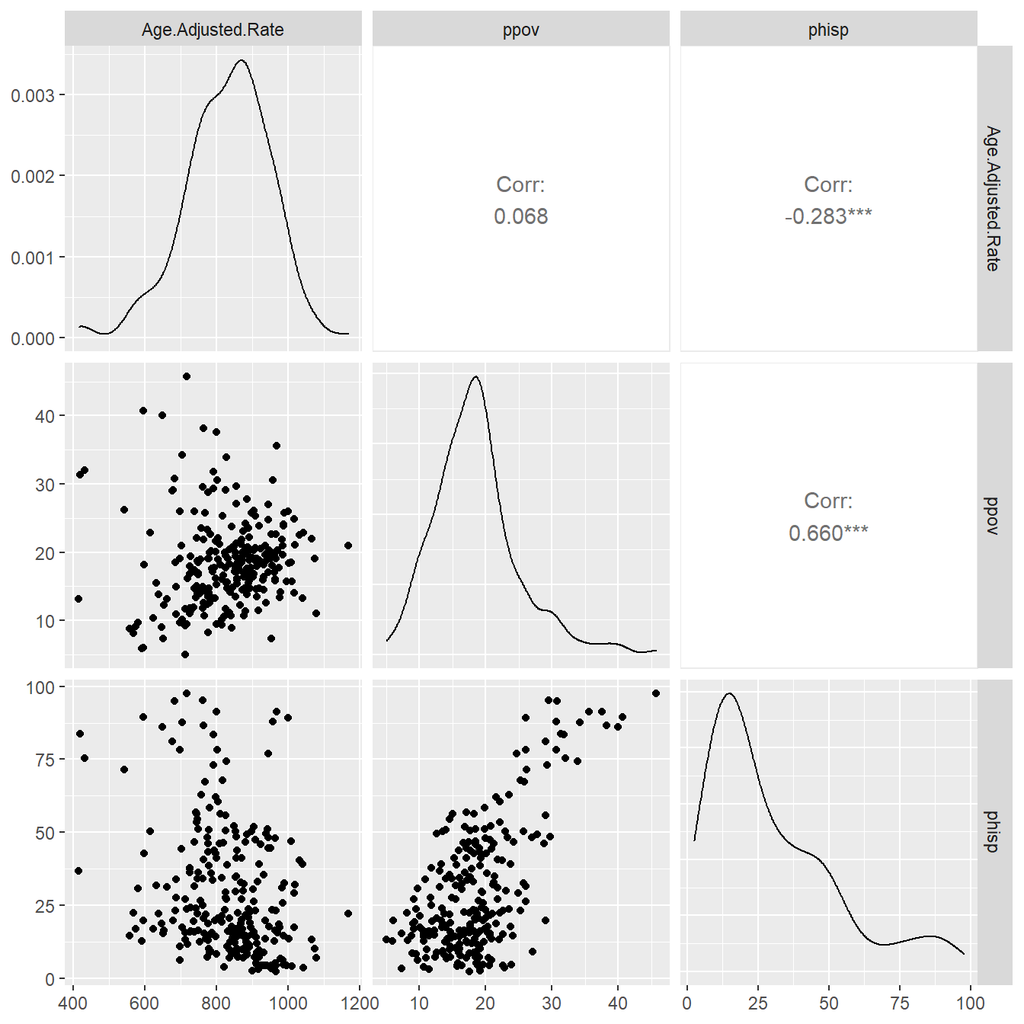

```r
usd<-usco
st_geometry(usd)<-NULL
usd%>%
  select(Age.Adjusted.Rate, ppov,phisp, state)%>%
  filter(complete.cases(.), state=="48")%>%
  select(Age.Adjusted.Rate, ppov,phisp)%>%
  ggpairs()
```

## Hierarchical clustering

First we form our matrix of distances between all the counties on our observed variables:

```r
usd_sub<-usd%>%
  select(Age.Adjusted.Rate, ppov,phisp, state)%>%
  filter(complete.cases(.), state =="48")

dmat<-dist(usd_sub[, -4],
           method="euclidean") #-4 drops state from the calculations
```

Then we run a hierarhical clustering algorithm on the matrix. There are lots of different ways to do this, we will just use the simplest method, the single-linkage, or nearest neighbor approach. This works by first sorting the distances from smallest to largest, then making clusters from the smallest distance pair.

Once this is done, this pair is merged into a cluster, their distance is then compared to the remaining observations, so on and so on, until you have a set of clusters for every observation.

The original way to plot these analyses is by a **dendrogram**, or tree plot.

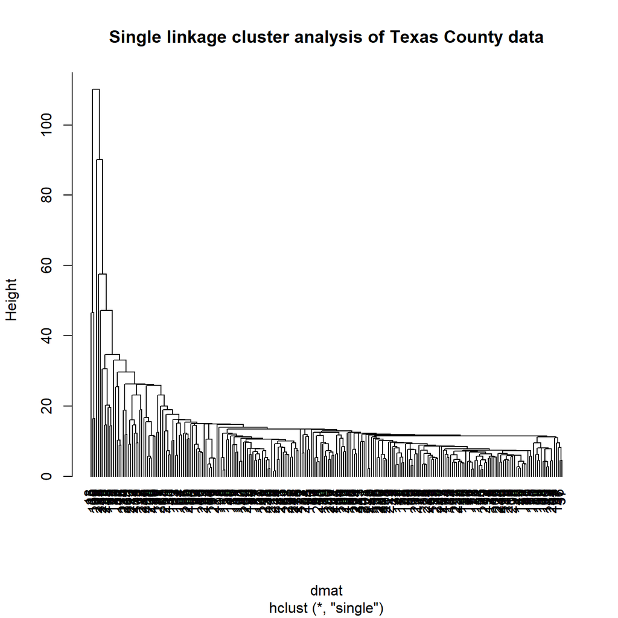

```r
hc1<-hclust(d= dmat,
            method="single")
plot(hc1,
     hang=-1,
     main="Single linkage cluster analysis of Texas County data")
```

```r
library(scorecard)
library(factoextra)
```

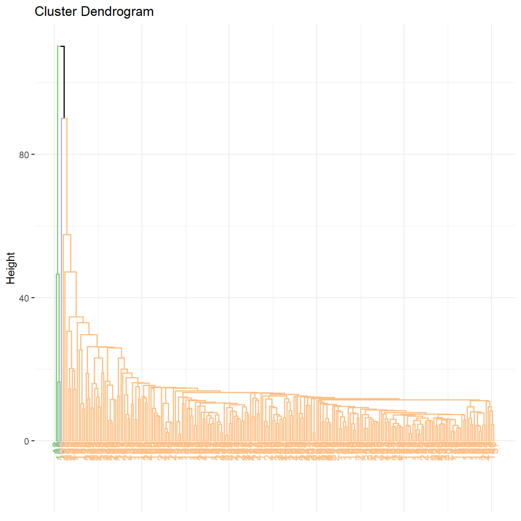

```r
library(class)
library(RColorBrewer)

fviz_dend(hc1, k=3,
          k_colors =brewer.pal(n=3, name="Accent"),
          color_labels_by_k = TRUE,
          ggtheme = theme_minimal())
```

```r
groups<-cutree(hc1, k=3)
table(groups)
```

```
## groups
##   1   2   3
## 247   3   1
```

So this is silly because the method makes clusters that only had one observation. This is a weakness of the single linkage method, instead we use another method. Ward’s method is typically seen as a better alternative because it tends to find clusters of similar size.

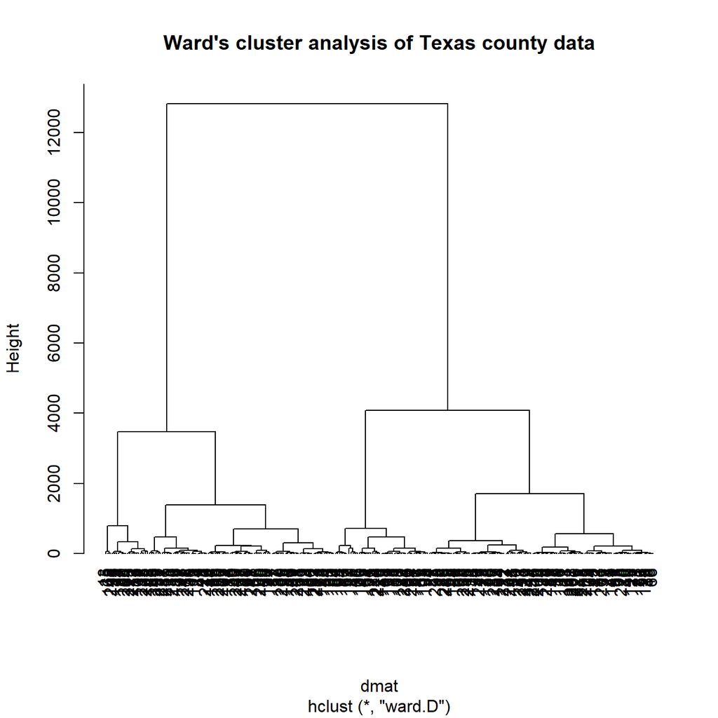

```r
hc2<-hclust(d= dmat, method="ward.D")
plot(hc2,
     hang=-1,
     main="Ward's cluster analysis of Texas county data")
```

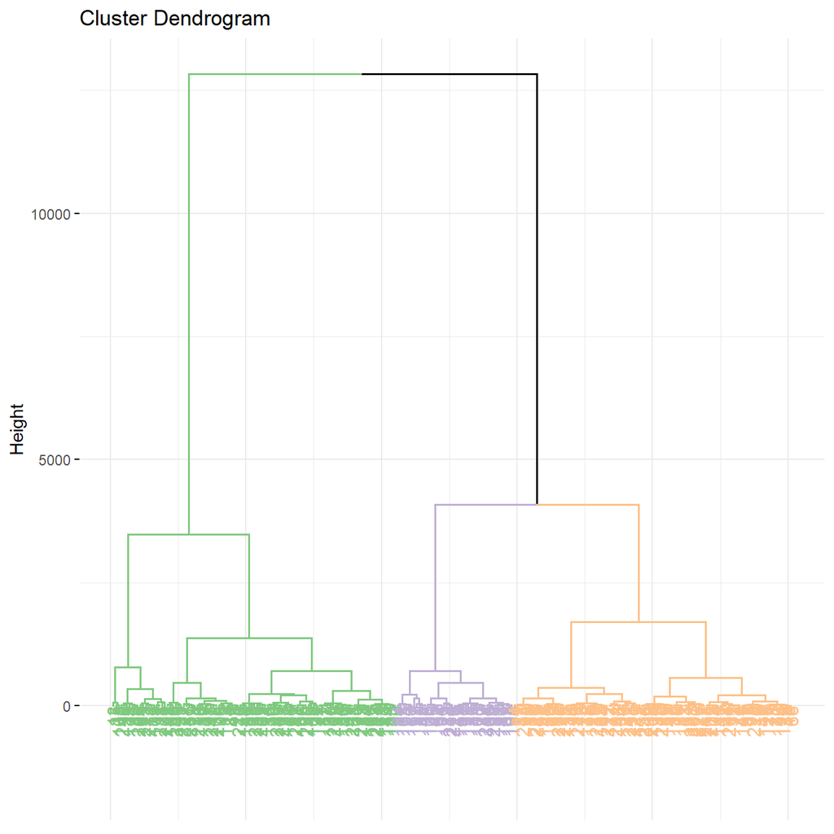

```r
fviz_dend(hc2, k=3,
          k_colors = brewer.pal(n=3, name="Accent"),
          color_labels_by_k = TRUE,
          ggtheme = theme_minimal())
```

```r
groups<-cutree(hc2, k=3)
table(groups)
```

```
## groups
##   1   2   3
## 103  43 105
```

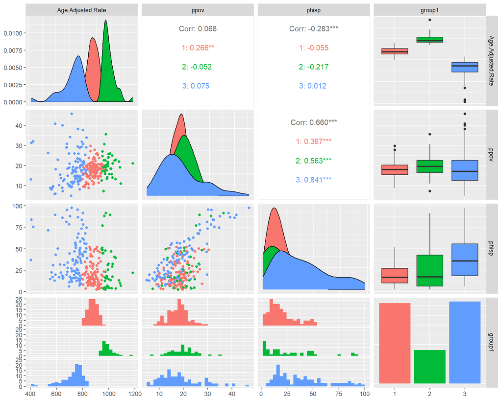

```r
usd_sub$group1<-factor(cutree(hc2, k=3))

usd_sub%>%
  select(-state)%>%
  ggpairs(aes(color=group1))
```

This seems to be splitting the data based on the mortality rate mostly. We can see what this looks like on the map as well:

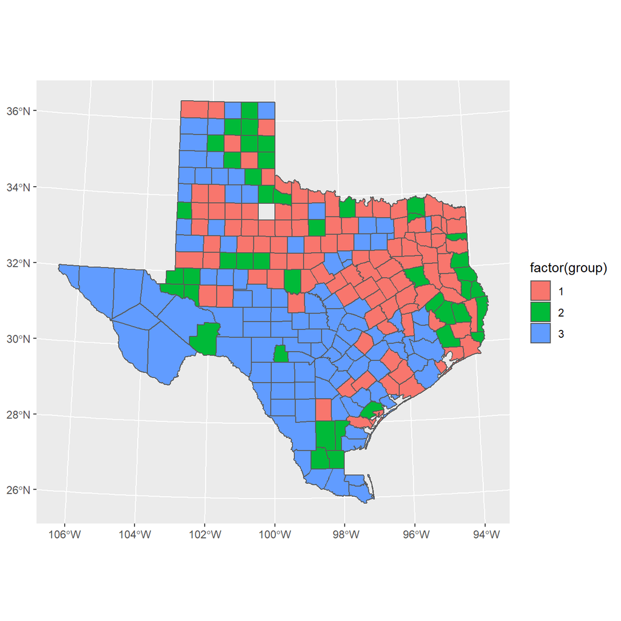

```r
tx<- usco%>%
  filter(state =="48", complete.cases(Age.Adjusted.Rate, phisp, ppov))

tx$group <- factor(cutree(hc2, k=3))

tx%>%
  ggplot()+
  geom_sf(aes(fill = factor(group)))
```

So we may be able to use these as regimes in an analysis.

## K-means

- Another type of clustering algorithm
- Will always find a given number of *k* clusters.
- Calculates the *centroid* of the data - mean vectors
- Assigns observations to the closest centroid.
- Ideally we can minimize a within cluster variance measure to find the optimal number, but there are other methods as well.

```r
library(ClusterR)
km2<-KMeans_rcpp(data=usd_sub[, c(1:3)], cluster=3, num_init = 10)
km2
```

```
## $clusters
##   [1] 2 3 2 2 3 3 3 2 3 3 2 2 1 3 3 2 3 2 1 2 2 3 3 3 3 3 2 2 2 3 3 3 3 2 1 2 3
##  [38] 2 3 3 2 3 3 2 2 2 3 2 3 2 3 3 3 2 3 1 2 2 2 3 3 2 3 1 2 2 3 2 2 3 2 1 2 1
##  [75] 1 2 3 2 2 2 3 2 3 3 3 2 3 1 3 3 3 2 2 2 3 2 2 3 2 2 3 3 2 2 3 2 3 2 1 3 3
## [112] 1 3 3 2 3 2 2 1 3 3 2 2 2 2 2 2 2 1 3 1 1 2 2 3 3 3 2 2 3 3 3 2 3 2 3 2 3
## [149] 3 3 2 3 3 3 3 2 2 1 2 2 2 3 2 2 2 3 2 1 3 2 2 3 2 2 3 2 2 3 3 2 2 3 1 3 3
## [186] 3 2 1 1 3 3 1 1 2 2 2 3 3 3 3 3 1 2 2 3 1 3 3 3 1 1 1 3 2 2 3 2 3 3 2 3 2
## [223] 1 2 3 3 1 2 2 2 3 1 3 3 2 3 2 3 3 3 2 1 3 2 2 3 3 3 1 3 1
##
## $centroids
##          [,1]     [,2]     [,3]
## [1,] 622.1155 18.37576 40.34598
## [2,] 936.9653 19.05238 22.69474
## [3,] 792.5962 18.04690 32.98306
##
## $total_SSE
## [1] 3677574
##
## $best_initialization
## [1] 9
##
## $WCSS_per_cluster
##        [,1]     [,2]     [,3]
## [1,] 234875 368667.7 278363.1
##
## $obs_per_cluster
##      [,1] [,2] [,3]
## [1,]   33  105  113
##
## $between.SS_DIV_total.SS
## [1] 0.7601936
##
## attr(,"class")
## [1] "k-means clustering"
```

```r
usd_sub$cluster<-as.factor(km2$cluster)
```

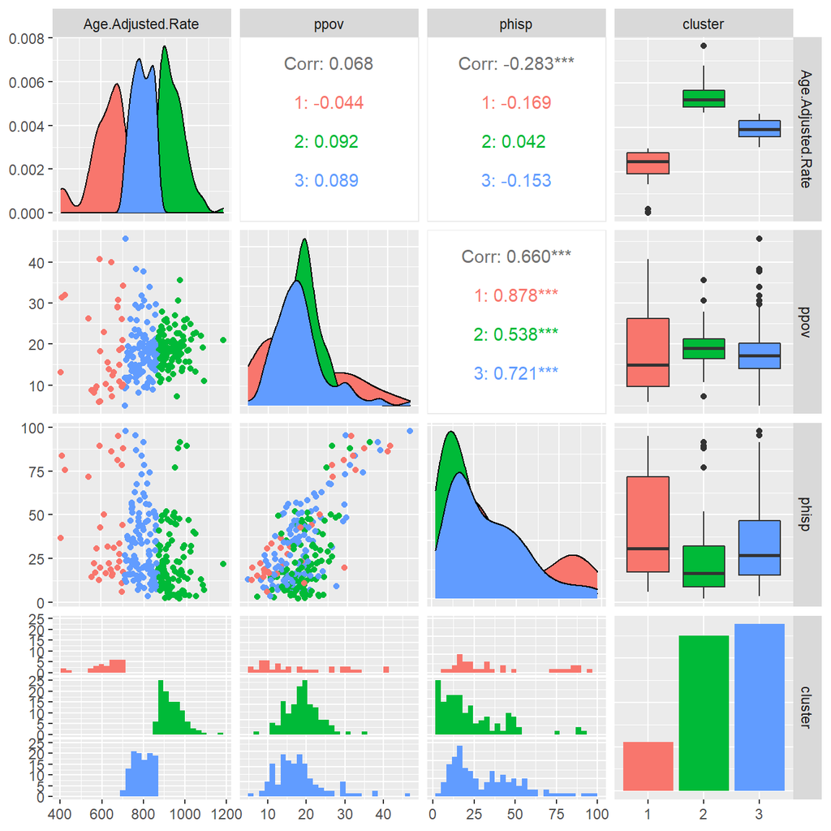

```r
usd_sub%>%
  select(-state, -group1)%>%
  ggpairs(aes(color=cluster))
```

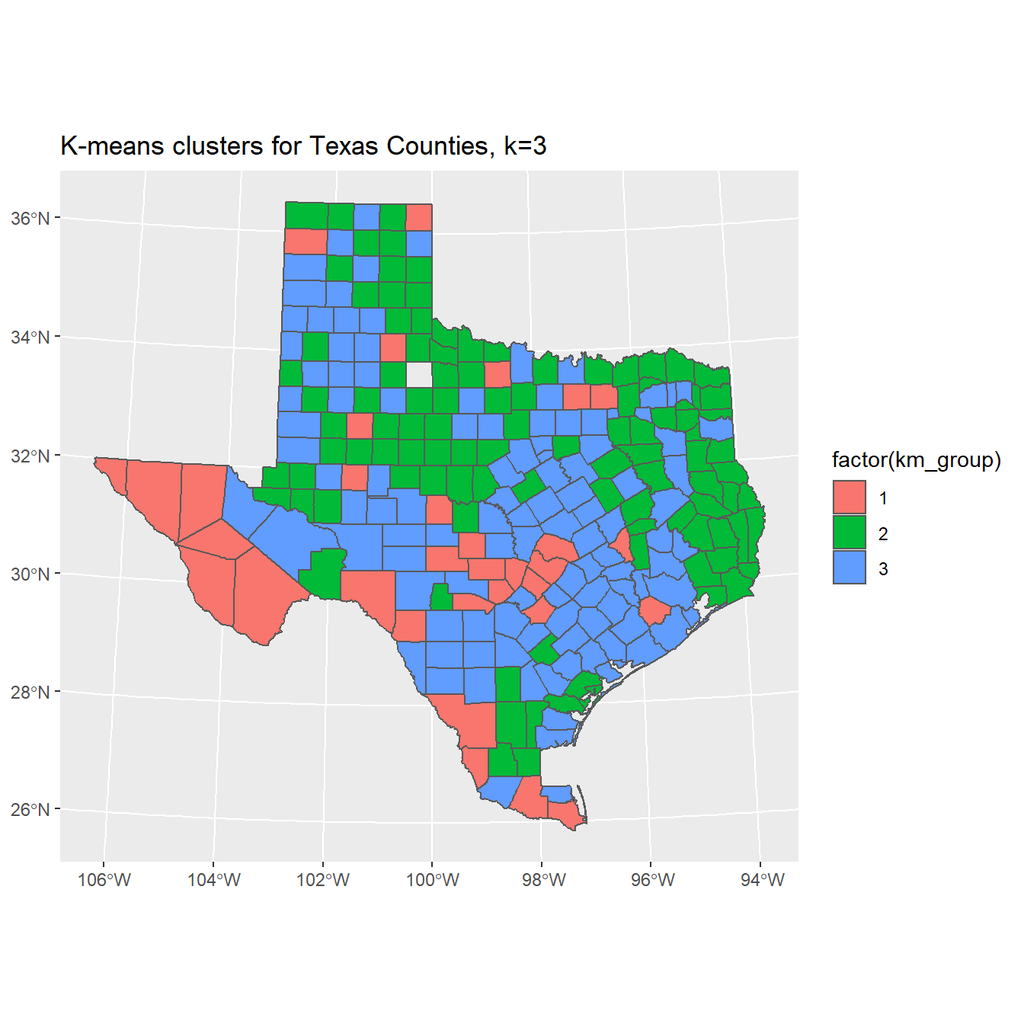

```r
tx$km_group <- as.factor(km2$cluster)
tx%>%
  ggplot()+
  geom_sf(aes(fill = factor(km_group)))+
  ggtitle("K-means clusters for Texas Counties, k=3")
```

### Finding optimal number of clusters

Here I use the `factoextra` package to compute various fit statistics for different number of clusters. The first is the so-called *elbow method*, because it resembles an elbow on an arm. It plots the within cluster variation versus the number of clusters.

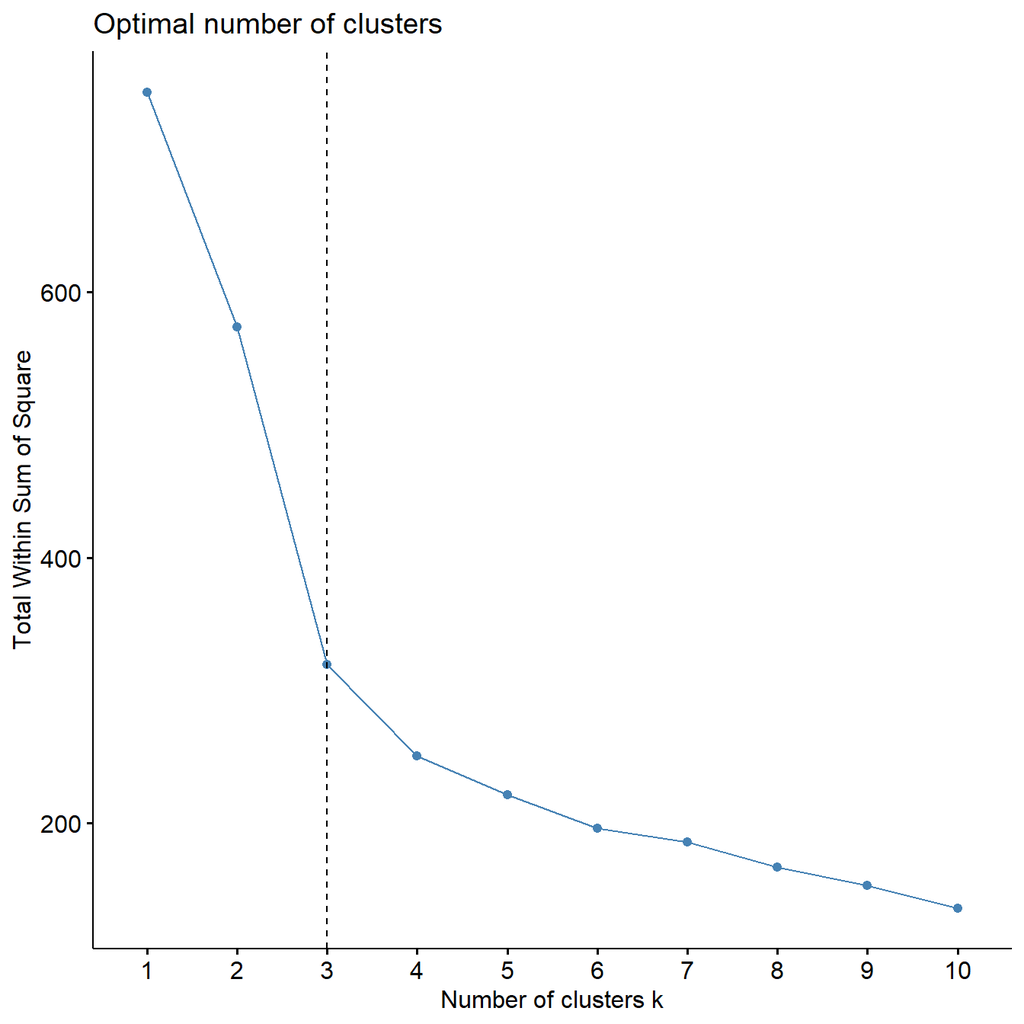

```r
library("factoextra")
my_data <- scale(usd_sub[, c(1:3)])

fviz_nbclust(my_data, kmeans, method = "wss") +
geom_vline(xintercept = 3, linetype = 2)
```

*Silhouette method* Other methods are the *silhouette method*, which displays a measure of how close each point in one cluster is to points in the neighboring clusters. Silhouette coefficients (as these values are referred to as) near +1 indicate that the sample is far away from the neighboring clusters.

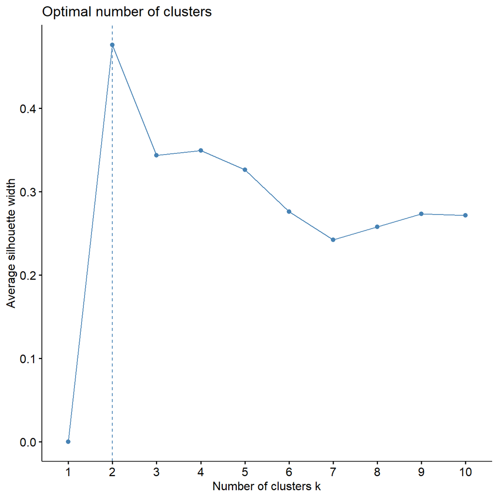

```r
fviz_nbclust(my_data, kmeans, method = "silhouette")
```

*Gap statistic* The gap statistic compares the patterns of observed distances between members of a cluster to those produced by simulating random observations. The estimate of the optimal clusters $k$ will be the value that maximizes the *Gap statistic*

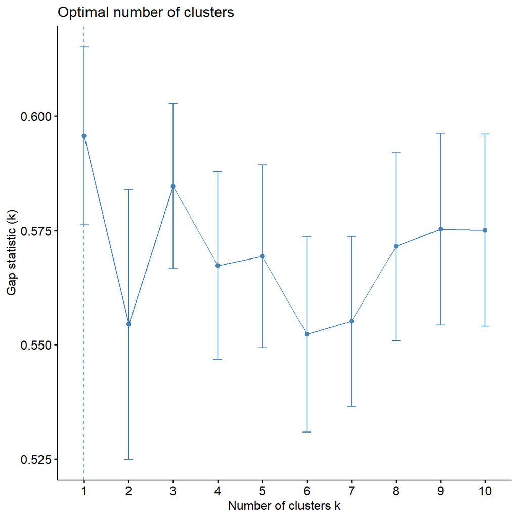

```r
fviz_nbclust(my_data, kmeans, method = "gap_stat")
```